# 1. Data Understanding and Exploratory Data Analysis (EDA)

Initial Data Loading and Inspection:

```
Loaded the dataset into R for analysis.
Examined the first few rows to get an initial understanding of the data's structure and content.
Summary Statistics:

Analyzed summary statistics for each column to understand the distribution and range of values.
Noted key aspects such as:
Age ranges from 19 to 42 years, indicating a wide range of player ages.
GP (Games Played) and W (Wins) vary significantly among players, suggesting differences in player participation and team performance.
PTS (Points) shows a broad range, highlighting the varying scoring contributions of players.
Field goal statistics (FGM, FGA, FG%) and three-point statistics (3PM, 3PA, 3P%) indicate players' shooting performance.
Free throw performance is captured by FTM, FTA, and FT%.
Rebound stats (OREB, DREB, REB) and AST (Assists) show players' contributions in other areas of the game.
Defensive actions are represented by STL (Steals), BLK (Blocks), and PF (Personal Fouls).
FP (Fantasy Points), DD2 (Double Doubles), and TD3 (Triple Doubles) offer insights into overall player performance and milestones.
The +/- column indicates the overall impact of a player during their time on the court.
Missing Values Check:

Confirmed that there are no missing values in the dataset, ensuring a complete dataset for analysis.
Distribution Analysis:

Employed histograms to visualize the distributions of key variables such as Age, PTS, and Min (Minutes Played), offering insights into the general trends and variances in these metrics.
Relationship Exploration:

Utilized scatter plots to explore relationships between variables, such as PTS vs. Min and Age vs. PTS, to understand how different aspects of player performance and attributes correlate with each other.
Positional Analysis:

Created boxplots to compare the distribution of PTS across different positions (POS), revealing positional variations in scoring contributions.
```

```r
# Load necessary libraries
library(tidyverse)
# Load the dataset
group_football_data <- read.csv("2023_nba_player_stats.csv")

# View the first few rows of the dataset
head(group_football_data)
```

```
##                     PName POS Team Age GP  W  L    Min  PTS FGM  FGA  FG. X3PM
## 1            Jayson Tatum  SF  BOS  25 74 52 22 2732.2 2225 727 1559 46.6  240
## 2             Joel Embiid   C  PHI  29 66 43 23 2284.1 2183 728 1328 54.8   66
## 3             Luka Doncic  PG  DAL  24 66 33 33 2390.5 2138 719 1449 49.6  185
## 4 Shai Gilgeous-Alexander  PG  OKC  24 68 33 35 2416.0 2135 704 1381 51.0   58
## 5   Giannis Antetokounmpo  PF  MIL  28 63 47 16 2023.6 1959 707 1278 55.3   47
## 6         Anthony Edwards  SG  MIN  21 79 40 39 2841.5 1946 707 1541 45.9  213
##   X3PA X3P. FTM FTA  FT. OREB DREB REB AST TOV STL BLK  PF   FP DD2 TD3 X...
## 1  686 35.0 531 622 85.4   78  571 649 342 213  78  51 160 3691  31   1  470
## 2  200 33.0 661 771 85.7  113  557 670 274 226  66 112 205 3706  39   1  424
## 3  541 34.2 515 694 74.2   54  515 569 529 236  90  33 166 3747  36  10  128
## 4  168 34.5 669 739 90.5   59  270 329 371 192 112  65 192 3425   3   0  149
## 5  171 27.5 498 772 64.5  137  605 742 359 246  52  51 197 3451  46   6  341
## 6  578 36.9 319 422 75.6   47  411 458 350 259 125  58 186 3311   9   0   97
```

```r
# Summary of the data
summary(group_football_data)
```

```
##     PName               POS                Team                Age
##  Length:539         Length:539         Length:539         Min.   :19.00
##  Class :character   Class :character   Class :character   1st Qu.:23.00
##  Mode  :character   Mode  :character   Mode  :character   Median :25.00
##                                                           Mean   :25.97
##                                                           3rd Qu.:29.00
##                                                           Max.   :42.00
##        GP              W               L              Min
##  Min.   : 1.00   Min.   : 0.00   Min.   : 0.00   Min.   :   1.0
##  1st Qu.:30.50   1st Qu.:12.00   1st Qu.:14.00   1st Qu.: 329.0
##  Median :54.00   Median :25.00   Median :25.00   Median : 970.2
##  Mean   :48.04   Mean   :24.02   Mean   :24.02   Mean   :1103.6
##  3rd Qu.:68.00   3rd Qu.:36.00   3rd Qu.:34.00   3rd Qu.:1845.9
##  Max.   :83.00   Max.   :57.00   Max.   :60.00   Max.   :2963.2
##       PTS              FGM             FGA              FG.
##  Min.   :   0.0   Min.   :  0.0   Min.   :   0.0   Min.   :  0.00
##  1st Qu.: 120.5   1st Qu.: 45.5   1st Qu.:  93.5   1st Qu.: 41.65
##  Median : 374.0   Median :138.0   Median : 300.0   Median : 45.50
##  Mean   : 523.4   Mean   :191.6   Mean   : 403.0   Mean   : 46.33
##  3rd Qu.: 769.5   3rd Qu.:283.5   3rd Qu.: 598.5   3rd Qu.: 50.60
##  Max.   :2225.0   Max.   :728.0   Max.   :1559.0   Max.   :100.00
##       X3PM             X3PA            X3P.             FTM
##  Min.   :  0.00   Min.   :  0.0   Min.   :  0.00   Min.   :  0.00
##  1st Qu.:  5.00   1st Qu.: 17.0   1st Qu.: 28.10   1st Qu.: 13.50
##  Median : 36.00   Median :109.0   Median : 34.20   Median : 42.00
##  Mean   : 56.32   Mean   :156.1   Mean   : 31.53   Mean   : 83.95
##  3rd Qu.: 92.00   3rd Qu.:249.5   3rd Qu.: 38.50   3rd Qu.:113.50
##  Max.   :301.00   Max.   :731.0   Max.   :100.00   Max.   :669.00
##       FTA             FT.              OREB             DREB
##  Min.   :  0.0   Min.   :  0.00   Min.   :  0.00   Min.   :  0.0
##  1st Qu.: 18.0   1st Qu.: 66.70   1st Qu.: 10.00   1st Qu.: 36.5
##  Median : 60.0   Median : 76.30   Median : 33.00   Median :118.0
##  Mean   :107.4   Mean   : 71.99   Mean   : 47.62   Mean   :150.6
##  3rd Qu.:147.0   3rd Qu.: 84.10   3rd Qu.: 63.00   3rd Qu.:229.5
##  Max.   :772.0   Max.   :100.00   Max.   :274.00   Max.   :744.0
##       REB             AST             TOV             STL
##  Min.   :  0.0   Min.   :  0.0   Min.   :  0.0   Min.   :  0.00
##  1st Qu.: 50.5   1st Qu.: 22.0   1st Qu.: 14.5   1st Qu.:  8.50
##  Median :159.0   Median : 69.0   Median : 44.0   Median : 28.00
##  Mean   :198.3   Mean   :115.5   Mean   : 61.3   Mean   : 33.27
##  3rd Qu.:286.0   3rd Qu.:162.5   3rd Qu.: 92.5   3rd Qu.: 51.00
##  Max.   :973.0   Max.   :741.0   Max.   :300.0   Max.   :128.00
##       BLK               PF               FP            DD2
##  Min.   :  0.00   Min.   :  0.00   Min.   :  -1   Min.   : 0.000
##  1st Qu.:  5.00   1st Qu.: 32.00   1st Qu.: 254   1st Qu.: 0.000
##  Median : 13.00   Median : 86.00   Median : 810   Median : 0.000
##  Mean   : 21.24   Mean   : 91.18   Mean   :1037   Mean   : 4.011
##  3rd Qu.: 28.00   3rd Qu.:140.00   3rd Qu.:1646   3rd Qu.: 3.000
##  Max.   :193.00   Max.   :279.00   Max.   :3842   Max.   :65.000
##       TD3               X...
##  Min.   : 0.0000   Min.   :-642
##  1st Qu.: 0.0000   1st Qu.: -70
##  Median : 0.0000   Median :  -7
##  Mean   : 0.2208   Mean   :   0
##  3rd Qu.: 0.0000   3rd Qu.:  57
##  Max.   :29.0000   Max.   : 640
```

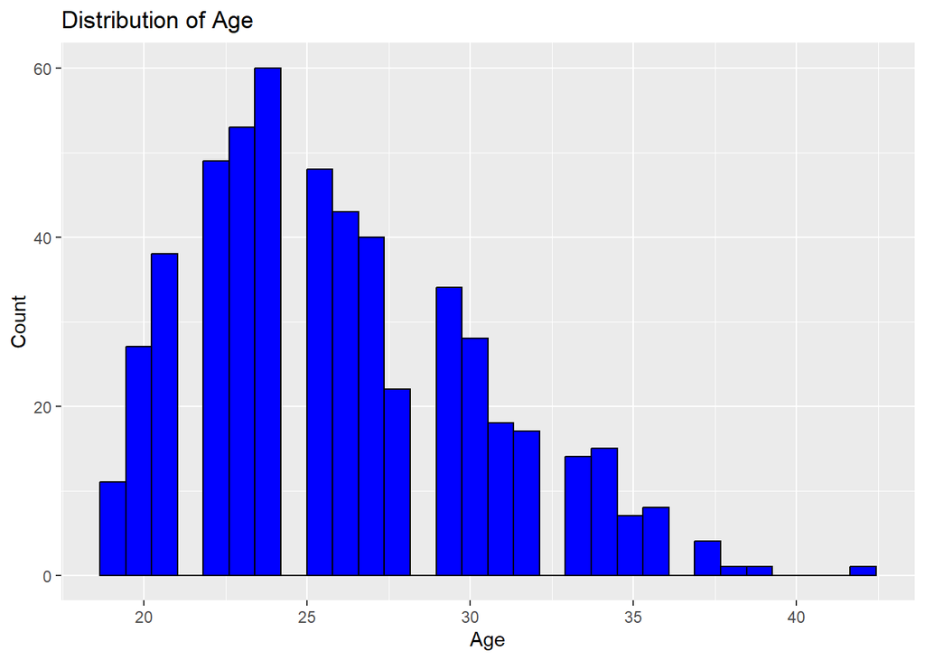

```r
# Histogram for Age
ggplot(group_football_data, aes(x = Age)) +
  geom_histogram(bins = 30, fill = "blue", color = "black") +
  labs(title = "Distribution of Age", x = "Age", y = "Count")
```

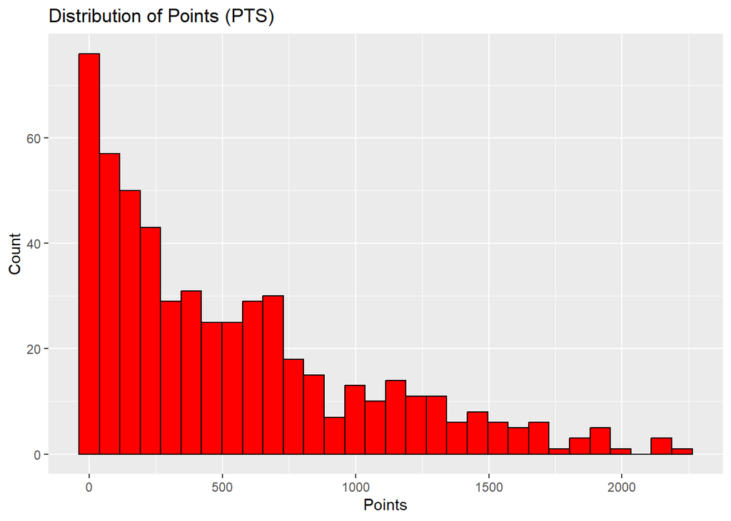

```r
# Histogram for Points (PTS)
ggplot(group_football_data, aes(x = PTS)) +
  geom_histogram(bins = 30, fill = "red", color = "black") +
  labs(title = "Distribution of Points (PTS)", x = "Points", y = "Count")
```

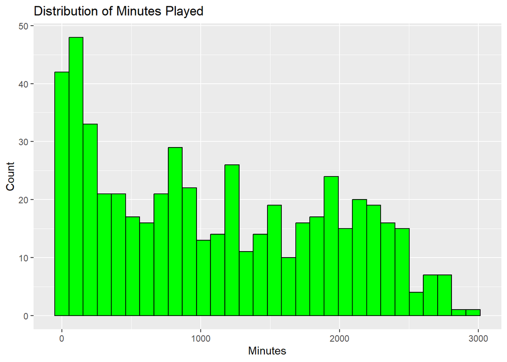

```r
# Histogram for Minutes Played (Min)
ggplot(group_football_data, aes(x = Min)) +
  geom_histogram(bins = 30, fill = "green", color = "black") +
  labs(title = "Distribution of Minutes Played", x = "Minutes", y = "Count")
```

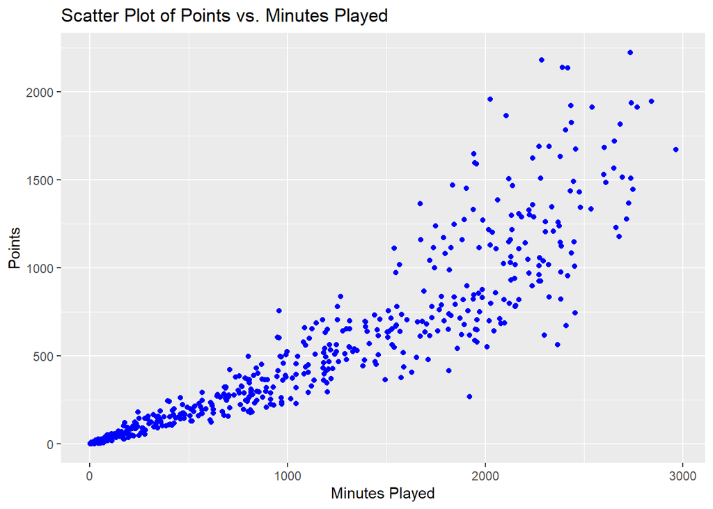

```r
# Scatter plot for PTS vs. Min
ggplot(group_football_data, aes(x = Min, y = PTS)) +
  geom_point(color = "blue") +
  labs(title = "Scatter Plot of Points vs. Minutes Played", x = "Minutes Played", y = "Points")
```

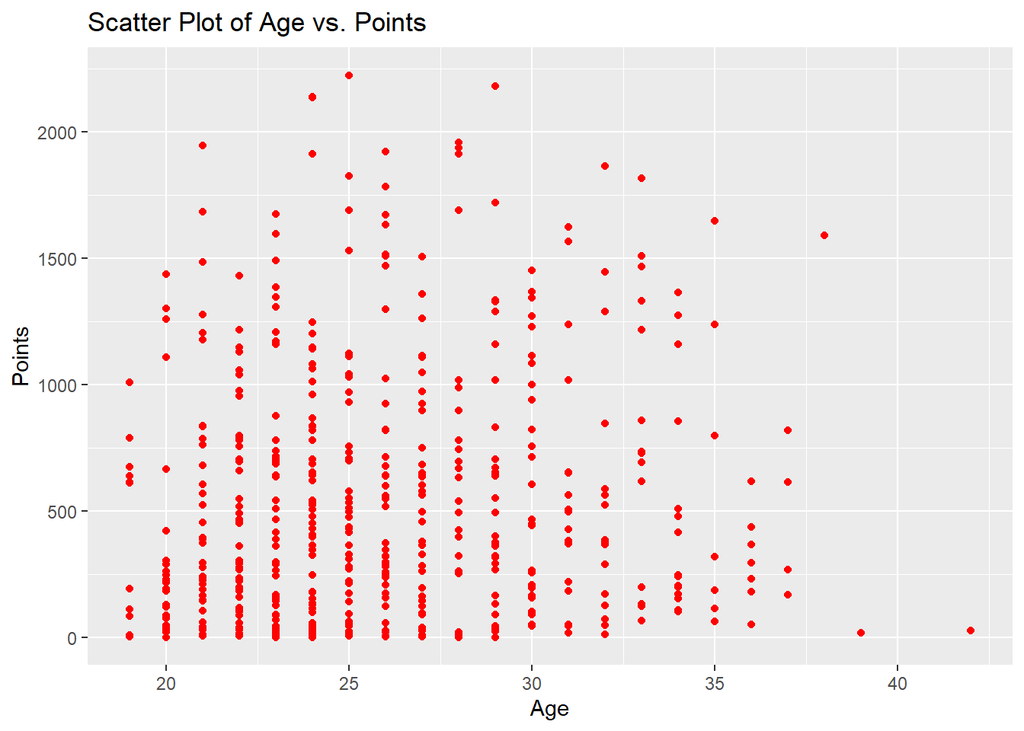

```r
# Scatter plot for Age vs. PTS
ggplot(group_football_data, aes(x = Age, y = PTS)) +
  geom_point(color = "red") +
  labs(title = "Scatter Plot of Age vs. Points", x = "Age", y = "Points")
```

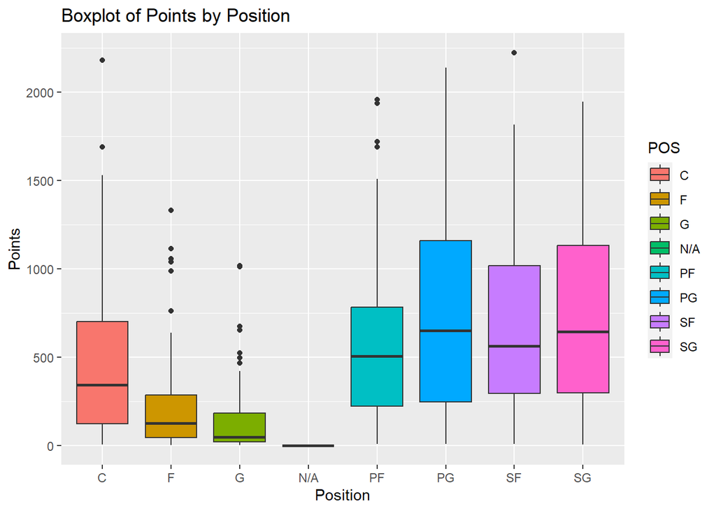

```r
# Boxplot for Points by Position
ggplot(group_football_data, aes(x = POS, y = PTS, fill = POS)) +
  geom_boxplot() +
  labs(title = "Boxplot of Points by Position", x = "Position", y = "Points")
```

# 2. Data Processing and Splitting

Missing Values Assessment:

Implemented Min-Max scaling to normalize numerical columns. This scaling technique transforms the data into a common range, typically 0 to 1, enhancing model performance by treating all features equally, especially important for models sensitive to the scale of data like Neural Networks. Feature Selection:

Excluded the ‘PName’ column from the dataset. Since ‘PName’ represents player names and acts as an identifier rather than a predictive feature, its removal helps focus the analysis on variables that contribute to player performance metrics. Dataset Splitting:

Split the processed data into training and testing sets. Used a 80-20 split ratio, ensuring a substantial amount of data for model training while retaining enough data to evaluate model performance. Applied set.seed(5555) to ensure reproducibility of results, meaning the same random subset of data will be selected for training and testing if the code is rerun. This section of the report highlights the critical steps taken in preparing the data for modeling. By handling missing values, normalizing data, and thoughtfully splitting the dataset, we establish a solid foundation for building reliable and robust predictive models.

```r
# Check for missing values
sum(is.na(group_football_data))
```

```
## [1] 0
```

```r
# Handling missing values - removing rows with NA in 'POS'
group_football_data <- na.omit(group_football_data)

# Normalizing data - Example using Min-Max Scaling
normalize <- function(x) {
  return((x - min(x)) / (max(x) - min(x)))
}

# Normalize numerical columns
numerical_cols <- sapply(group_football_data, is.numeric)
group_football_data[numerical_cols] <- lapply(group_football_data[numerical_cols], normalize)
# Exclude the 'PName' column
group_football_data <- group_football_data[ , !(names(group_football_data) %in% c('PName'))]

# Splitting data into training and testing sets
set.seed(5555)
training_indices <- sample(1:nrow(group_football_data), 0.8 * nrow(group_football_data))
pitch_training_set <- group_football_data[training_indices, ]
pitch_test_set <- group_football_data[-training_indices, ]
```

# 3. Modelling

Library Preparation:

Loaded essential R libraries for various modeling techniques: caret for general modeling functions, nnet for Artificial Neural Networks (ANN), glmnet for Lasso and Ridge regression, and randomForest for Random Forest models. This step ensures access to a broad range of functions and algorithms for model development and evaluation. Modeling Strategy:

Established a modeling strategy focused on exploring different types of algorithms to understand which performs best for predicting player points (PTS). The diverse approach in algorithm selection aims to capture different aspects and complexities within the data. ANN Model (Goalie):

Developed an ANN model named “Goalie.” Chosen for its ability to learn non-linear relationships and complex patterns in the data. Configured with cross-validation (10-fold) to ensure robustness and generalizability. Upon training completion, printed a summary to review the model’s structure and key parameters. Lasso Regression (Midfielder):

Trained a Lasso regression model referred to as “Midfielder.” Selected for its proficiency in feature selection and preventing model overfitting through regularization. Utilized cross-validation for tuning and enhancing model reliability. Summarized the model post-training to inspect coefficients and model specifics. Random Forest (Striker):

Implemented a Random Forest model, named “Striker.” This ensemble learning method is known for handling a mix of data types and capturing complex interactions between variables. Random Forest models are also beneficial for their inherent feature importance measures. Reviewed the model’s summary to evaluate its construction and feature importance.

```r
# Load necessary libraries for modeling
library(caret)
library(nnet)  # For ANN
library(glmnet)  # For Lasso and Ridge
library(randomForest)  # For Random Forest
# Define the formula
scoring_formula <- PTS ~ .

# Train different models - example with ANN, Lasso, and Random Forest
# ANN model (Goalie)
model_goalie <- train(scoring_formula, data=pitch_training_set, method="nnet", trControl=trainControl(method="cv", number=10))
print(summary(model_goalie))
```

[output not shown]

[output cut: 19 more lines]

[output not shown]

```r
# Lasso regression (Midfielder)
model_midfielder <- train(scoring_formula, data=pitch_training_set, method="glmnet", trControl=trainControl(method="cv", number=10))

print(summary(model_midfielder))
```

```
##             Length Class      Mode
## a0            41   -none-     numeric
## beta        2542   dgCMatrix  S4
## df            41   -none-     numeric
## dim            2   -none-     numeric
## lambda        41   -none-     numeric
## dev.ratio     41   -none-     numeric
## nulldev        1   -none-     numeric
## npasses        1   -none-     numeric
## jerr           1   -none-     numeric
## offset         1   -none-     logical
## call           5   -none-     call
## nobs           1   -none-     numeric
## lambdaOpt      1   -none-     numeric
## xNames        62   -none-     character
## problemType    1   -none-     character
## tuneValue      2   data.frame list
## obsLevels      1   -none-     logical
## param          0   -none-     list
```

```r
# Random Forest (Striker)
model_striker <- randomForest(scoring_formula, data=pitch_training_set)

print(summary(model_striker))
```

```
##                 Length Class  Mode
## call              3    -none- call
## type              1    -none- character
## predicted       431    -none- numeric
## mse             500    -none- numeric
## rsq             500    -none- numeric
## oob.times       431    -none- numeric
## importance       28    -none- numeric
## importanceSD      0    -none- NULL
## localImportance   0    -none- NULL
## proximity         0    -none- NULL
## ntree             1    -none- numeric
## mtry              1    -none- numeric
## forest           11    -none- list
## coefs             0    -none- NULL
## y               431    -none- numeric
## test              0    -none- NULL
## inbag             0    -none- NULL
## terms             3    terms  call
```

# 4. Model Validation

Test Set Predictions:

Conducted predictions on the test set (pitch_test_set) using all three models: Goalie (ANN), Midfielder (Lasso Regression), and Striker (Random Forest). This process evaluates how well each model generalizes to new, unseen data, which is critical for assessing their real-world applicability. Performance Metric - RMSE:

Calculated the Root Mean Squared Error (RMSE) for each model to quantify their prediction accuracy. RMSE provides a clear measure of the models’ prediction errors, with lower values indicating better performance.

```r
# Predicting and evaluating the models on the test set
predictions_goalie <- predict(model_goalie, newdata=pitch_test_set)
predictions_midfielder <- predict(model_midfielder, newdata=pitch_test_set)
predictions_striker <- predict(model_striker, newdata=pitch_test_set)

# Calculating RMSE
score_goalie <- sqrt(mean((predictions_goalie - pitch_test_set$PTS)^2))
score_midfielder <- sqrt(mean((predictions_midfielder - pitch_test_set$PTS)^2))
score_striker <- sqrt(mean((predictions_striker - pitch_test_set$PTS)^2))
```

# 5. Performance Reporting

Reporting RMSE Values:

Residual Analysis:

Visualized residuals for each model using scatter plots. These plots compare predicted points against the residuals (differences between predicted and actual points). Residual plots are crucial for identifying patterns in prediction errors, indicating model strengths and areas for improvement.

```r
# Print RMSE values
print(paste("RMSE Goalie:", score_goalie))
```

```
## [1] "RMSE Goalie: 0.0323247651312506"
```

```r
print(paste("RMSE Midfielder:", score_midfielder))
```

```
## [1] "RMSE Midfielder: 0.00552793306676987"
```

```r
print(paste("RMSE Striker:", score_striker))
```

```
## [1] "RMSE Striker: 0.0139360981988869"
```

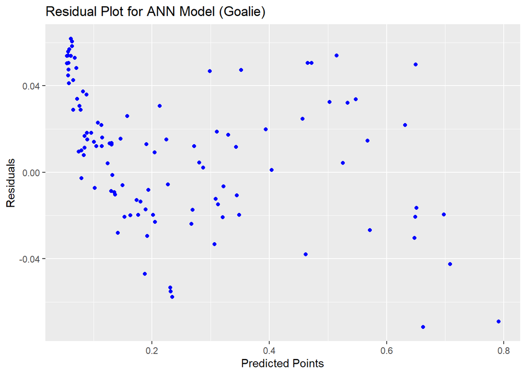

```r
# Residual plot for ANN model (Goalie)
ggplot() +
  geom_point(aes(x = predictions_goalie, y = predictions_goalie - pitch_test_set$PTS),
             colour = "blue") +
  labs(title = "Residual Plot for ANN Model (Goalie)",
       x = "Predicted Points",
       y = "Residuals")
```

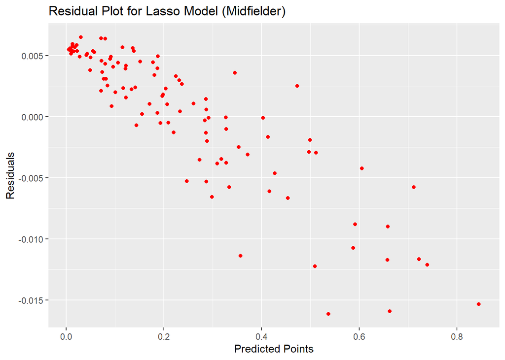

```r
# Residual plot for Lasso model (Midfielder)
ggplot() +
  geom_point(aes(x = predictions_midfielder, y = predictions_midfielder - pitch_test_set$PTS),
             colour = "red") +
  labs(title = "Residual Plot for Lasso Model (Midfielder)",
       x = "Predicted Points",
       y = "Residuals")
```

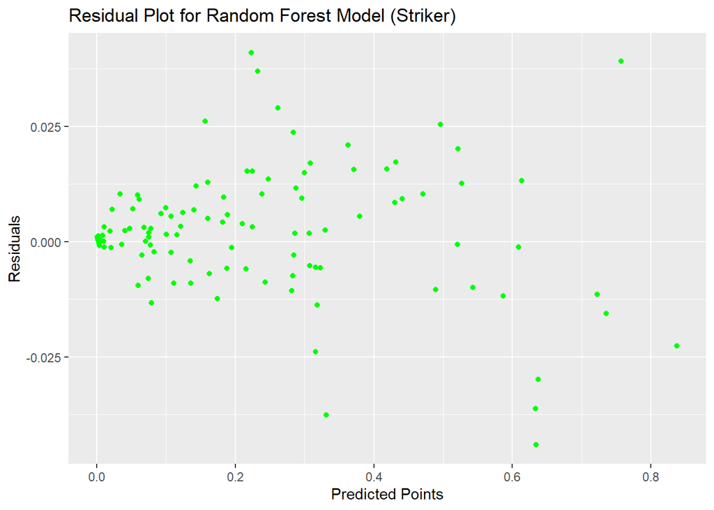

```r
# Residual plot for Random Forest model (Striker)
ggplot() +
  geom_point(aes(x = predictions_striker, y = predictions_striker - pitch_test_set$PTS),
             colour = "green") +
  labs(title = "Residual Plot for Random Forest Model (Striker)",
       x = "Predicted Points",
       y = "Residuals")
```

# 6. Conclusion

Summary of Findings:

The project successfully implemented and compared three different predictive models: ANN, Lasso Regression, and Random Forest. The Midfielder (Lasso Regression) model demonstrated the highest accuracy in predicting player points (PTS), as indicated by its lowest RMSE value.

Model Evaluation:

All models showed varying degrees of prediction accuracy, with each having unique strengths. The Lasso Regression model (Midfielder) was particularly effective, likely due to its ability to handle multicollinearity and select relevant features. The Random Forest model (Striker) also performed well, benefiting from its ensemble approach and ability to capture non-linear relationships.

Future Recommendations:

Further exploration of hyperparameter tuning and feature engineering could potentially enhance model performances. Additional models, such as Gradient Boosting or Support Vector Machines, could be explored to compare and potentially improve results. Investigating interactions and more complex relationships within the data might reveal additional insights and improve predictions.

Final Thoughts:

The project underscores the importance of a thorough approach to data preparation, model selection, and evaluation in predictive modeling. The insights gained from this analysis could be invaluable for strategic decision-making in contexts where understanding player performance is crucial.